# Curso propedéutico de Probabilidad y Estadística

Martin Eduardo Preciado Orozco

2023-06-11

#### Probabilidad y Estadística - Curso Propedeutico para Maestría en Ciencia de Datos

### 1. Selección del problema:

Identificar un problema relevante en el campo de la ciencia de datos, que pueda abordarse mediante métodos estadísticos.

En la industria automotriz siempre se busca optimizar los procesos para satisfacer a los clientes con la mejor eficiencia posible en sus productos, en este proyecto buscaremos si existe una relacion entre las variables que miden la eficiencia del combustible para encontrar areas de mejora y un uso optimo.

### 2. Descripción del problema:

Detallar claramente el problema a investigar, incluyendo su contexto, antecedentes, especificando la(s) variable(s) que se utilizan en la problemática planteada

Esta base de datos trata sobre la eficiencia del combustible de carros a partir de las siguientes variables: - MPG: Millas por galon - GPM: Galones por 100 millas - WT: Peso del carro (en 1000 lb) - DIS: Desplazamiento cubico (en pulgadas cubicas) - NC: Numero de cilindros - HP: Caballos de potencia - ACC: Aceleracion (Segundos transcurridos de 0 a 60 mph) - ET: Tipo de motor (en V o linea (codificado en 1))

Lo que se quiere lograr con esta base de datos es encontrar si las millas por galon dependen de alguna variable

```r
rm(list=ls())

setwd("C:/Users/marti/Desktop/python_work/CSVs")

Datos <- read.csv("FuelEfficiency.csv", header = TRUE, sep = ",", dec = ".")
head(Datos)
```

```
##    MPG   GPM    WT DIS NC  HP  ACC ET
## 1 16.9 5.917 4.360 350  8 155 14.9  1
## 2 15.5 6.452 4.054 351  8 142 14.3  1
## 3 19.2 5.208 3.605 267  8 125 15.0  1
## 4 18.5 5.405 3.940 360  8 150 13.0  1
## 5 30.0 3.333 2.155  98  4  68 16.5  0
## 6 27.5 3.636 2.560 134  4  95 14.2  0
```

```r
str(Datos)
```

```
## 'data.frame':    38 obs. of  8 variables:
##  $ MPG: num  16.9 15.5 19.2 18.5 30 27.5 27.2 30.9 20.3 17 ...
##  $ GPM: num  5.92 6.45 5.21 5.41 3.33 ...
##  $ WT : num  4.36 4.05 3.6 3.94 2.15 ...
##  $ DIS: int  350 351 267 360 98 134 119 105 131 163 ...
##  $ NC : int  8 8 8 8 4 4 4 4 5 6 ...
##  $ HP : int  155 142 125 150 68 95 97 75 103 125 ...
##  $ ACC: num  14.9 14.3 15 13 16.5 14.2 14.7 14.5 15.9 13.6 ...
##  $ ET : int  1 1 1 1 0 0 0 0 0 0 ...
```

### 3. Objetivos:

Establecer los objetivos que se pretenden lograr con la investigación. Estos objetivos deben ser claros, medibles y estar alineados con el problema planteado.

Determinar si existe una diferencia significativa en la eficiencia del combustible (MPG) entre carros con motores en V y carros con motores en línea. - Métrica de medición: Valor p del análisis de varianza (ANOVA). - Meta: Obtener un valor p menor que 0.05 para rechazar la hipótesis nula.

### 4. Recopilación y limpieza de datos:

Si se utilizan datos reales para abordar el problema, es necesario describir detalladamente cómo se recopilaron los datos y qué medidas se tomaron para limpiarlos. Esto puede incluir la eliminación de datos faltantes, la detección y corrección de valores atípicos, la estandarización de formatos y cualquier otro paso necesario para garantizar la calidad de los datos utilizados. En caso de utilizar datos simulados, describir el proceso de simulación de éstos.

```r
library(skimr)

# Explorar completitud de base de datos
skim(Datos)
```

Data summary

| Name | Datos |
| --- | --- |
| Number of rows | 38 |
| Number of columns | 8 |
| _______________________ |  |
| Column type frequency: |  |
| numeric | 8 |
| ________________________ |  |
| Group variables | None |

**Variable type: numeric**

| skim_variable | n_missing | complete_rate | mean | sd | p0 | p25 | p50 | p75 | p100 | hist |
| --- | --- | --- | --- | --- | --- | --- | --- | --- | --- | --- |
| MPG | 0 | 1 | 24.76 | 6.55 | 15.50 | 18.52 | 24.25 | 30.38 | 37.30 | ▇▅▃▅▃ |
| GPM | 0 | 1 | 4.33 | 1.16 | 2.68 | 3.29 | 4.16 | 5.40 | 6.45 | ▇▅▅▃▃ |
| WT | 0 | 1 | 2.86 | 0.71 | 1.92 | 2.21 | 2.68 | 3.41 | 4.36 | ▇▇▂▅▂ |
| DIS | 0 | 1 | 177.29 | 88.88 | 85.00 | 105.00 | 148.50 | 229.50 | 360.00 | ▇▃▁▂▂ |
| NC | 0 | 1 | 5.39 | 1.60 | 4.00 | 4.00 | 4.50 | 6.00 | 8.00 | ▇▁▅▁▃ |
| HP | 0 | 1 | 101.74 | 26.44 | 65.00 | 78.50 | 100.00 | 123.75 | 155.00 | ▇▅▅▅▂ |
| ACC | 0 | 1 | 14.86 | 1.56 | 11.30 | 14.03 | 14.80 | 15.78 | 19.20 | ▁▆▇▂▁ |
| ET | 0 | 1 | 0.29 | 0.46 | 0.00 | 0.00 | 0.00 | 1.00 | 1.00 | ▇▁▁▁▃ |

```r
library(mice)
```

[output not shown]

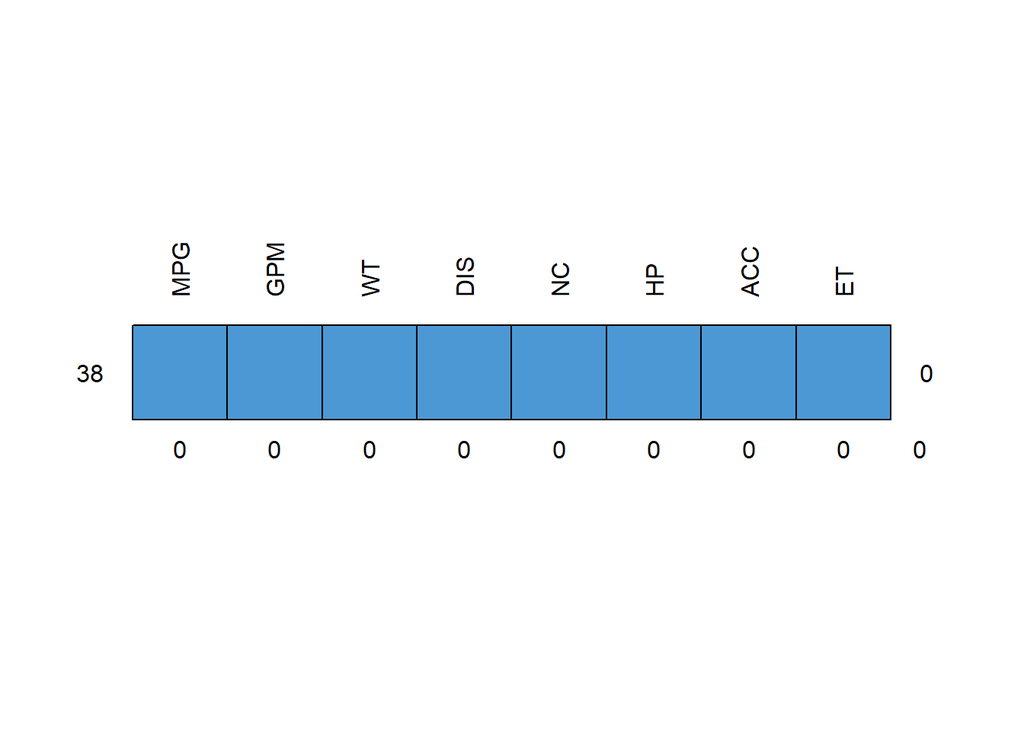

```
##    MPG GPM WT DIS NC HP ACC ET
## 38   1   1  1   1  1  1   1  1 0
##      0   0  0   0  0  0   0  0 0
```

```r
# Mostrar patron de datos ausentes (NA)
md.pattern(Datos, rotate.names = TRUE)
```

### 5. Estadística descriptiva:

Realizar un análisis descriptivo de los datos recolectados. Esto implica calcular medidas resumen (como promedios, medianas, desviaciones estándar, cuartiles, etc.), visualizar los datos mediante gráficos adecuados y realizar exploración inicial para comprender las características generales de los datos.

```r
summary(Datos)
```

```
##       MPG             GPM              WT             DIS
##  Min.   :15.50   Min.   :2.681   Min.   :1.915   Min.   : 85.0
##  1st Qu.:18.52   1st Qu.:3.292   1st Qu.:2.208   1st Qu.:105.0
##  Median :24.25   Median :4.160   Median :2.685   Median :148.5
##  Mean   :24.76   Mean   :4.331   Mean   :2.863   Mean   :177.3
##  3rd Qu.:30.38   3rd Qu.:5.398   3rd Qu.:3.410   3rd Qu.:229.5
##  Max.   :37.30   Max.   :6.452   Max.   :4.360   Max.   :360.0
##        NC              HP             ACC              ET
##  Min.   :4.000   Min.   : 65.0   Min.   :11.30   Min.   :0.0000
##  1st Qu.:4.000   1st Qu.: 78.5   1st Qu.:14.03   1st Qu.:0.0000
##  Median :4.500   Median :100.0   Median :14.80   Median :0.0000
##  Mean   :5.395   Mean   :101.7   Mean   :14.86   Mean   :0.2895
##  3rd Qu.:6.000   3rd Qu.:123.8   3rd Qu.:15.78   3rd Qu.:1.0000
##  Max.   :8.000   Max.   :155.0   Max.   :19.20   Max.   :1.0000
```

[figure not shown]

```r
par(mfrow=c(4,4))

# MPG
hist(Datos$MPG, freq = FALSE, col="deeppink4",
     main="MPG",
     ylab = "Densidad")
lines(density(Datos$MPG), col= "red")

# GPM
hist(Datos$GPM, freq = FALSE, col="deeppink4",
     main="GPM",
     ylab = "Densidad")
lines(density(Datos$GPM), col= "red")

# WT
hist(Datos$WT, freq = FALSE, col="deeppink4",
     main="WT",
     ylab = "Densidad")
lines(density(Datos$WT), col= "red")

# DIS
hist(Datos$DIS, freq = FALSE, col="deeppink4",
     main="DIS",
     ylab = "Densidad")
lines(density(Datos$DIS), col= "red")

# NC
hist(Datos$NC, freq = FALSE, col="deeppink4",
     main="NC",
     ylab = "Densidad")
lines(density(Datos$NC), col= "red")

# HP
hist(Datos$HP, freq = FALSE, col="deeppink4",
     main="HP",
     ylab = "Densidad")
lines(density(Datos$HP), col= "red")

# ACC
hist(Datos$ACC, freq = FALSE, col="deeppink4",
     main="ACC",
     ylab = "Densidad")
lines(density(Datos$ACC), col= "red")

# ET
hist(Datos$ET, freq = FALSE, col="deeppink4",
     main="ET",
     ylab = "Densidad")
lines(density(Datos$ET), col= "red")
```

### 6. Análisis estadístico inferencial:

Aplicar técnicas de estadística inferencial para obtener conclusiones más allá de lo observado de manera exploratoria. Esto podría implicar la realización de pruebas de hipótesis, intervalos de confianza, análisis de regresión, análisis de varianza, etc. En general técnicas estadísticas que considere adecuadas para el problema en cuestión.

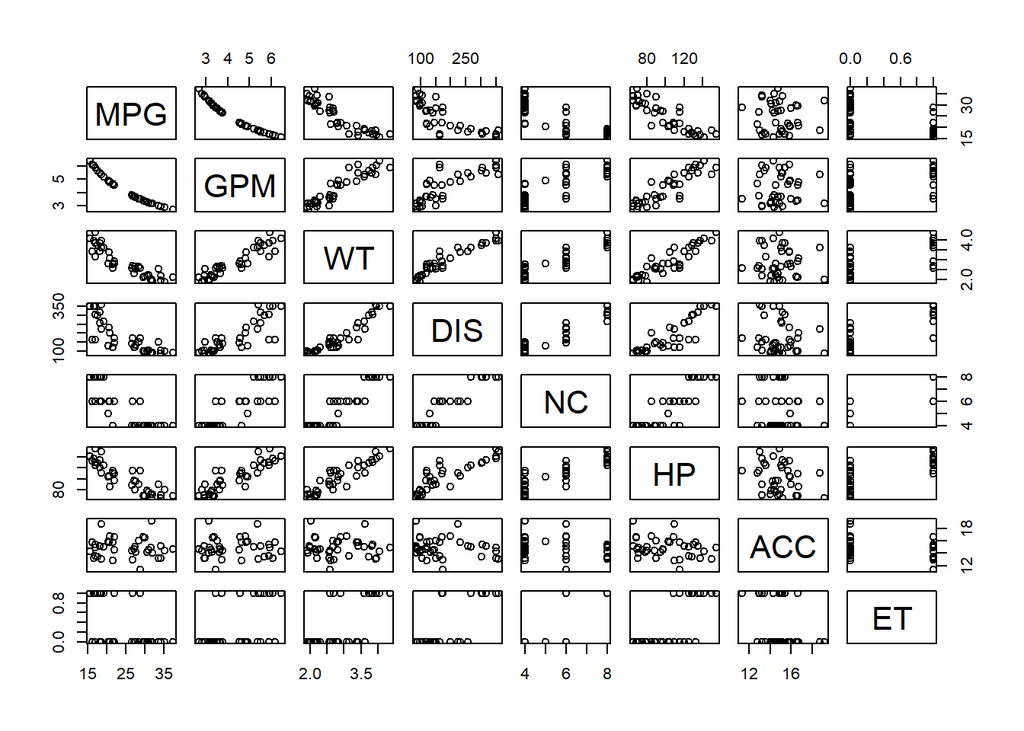

```r
pairs(Datos)
```

```r
library(dplyr)
library(stats)

modelo <- lm(MPG~., data = Datos[,-2])
summary(modelo)
```

```
##
## Call:
## lm(formula = MPG ~ ., data = Datos[, -2])
##
## Residuals:
##     Min      1Q  Median      3Q     Max
## -4.0235 -1.3967 -0.3233  0.9929  5.3405
##
## Coefficients:
##             Estimate Std. Error t value Pr(>|t|)
## (Intercept) 65.86701    4.58292  14.372 2.97e-15 ***
## WT          -6.09297    3.12198  -1.952  0.06007 .
## DIS          0.03981    0.01863   2.137  0.04058 *
## NC          -1.98786    0.84752  -2.346  0.02558 *
## HP          -0.13847    0.04657  -2.973  0.00566 **
## ACC         -0.47933    0.30543  -1.569  0.12672
## ET           4.19010    1.84300   2.274  0.03007 *
## ---
## Signif. codes:  0 '***' 0.001 '**' 0.01 '*' 0.05 '.' 0.1 ' ' 1
##
## Residual standard error: 2.162 on 31 degrees of freedom
## Multiple R-squared:  0.9086, Adjusted R-squared:  0.8909
## F-statistic: 51.37 on 6 and 31 DF,  p-value: 9.45e-15
```

```r
# Modelo anova
# Hipótesis: El rendimiento MPG depende del Número de cilindros (NC) y del tipo de motor (ET)

lmMPG <- lm(MPG~factor(NC)+factor(ET), data = Datos)
anovaMPG <- aov(lmMPG)
summary(anovaMPG)
```

```
##             Df Sum Sq Mean Sq F value   Pr(>F)
## factor(NC)   3 1111.6   370.5  32.381 6.01e-10 ***
## factor(ET)   1   96.8    96.8   8.462  0.00644 **
## Residuals   33  377.6    11.4
## ---
## Signif. codes:  0 '***' 0.001 '**' 0.01 '*' 0.05 '.' 0.1 ' ' 1
```

A partir de estos resultados que ninguno es mayor a 0.05 podemos rechazar nuestra hipotesis nula

### 7. Resultados y conclusiones:

Presentar los resultados de manera clara y concisa. Interpretar los resultados obtenidos en el contexto del problema planteado y los objetivos de la investigación.

En base al análisis realizado, se presentan los siguientes resultados y conclusiones:

Variables significativas: El número de cilindros (NC) y el tipo de motor (ET) mostraron ser variables significativas que impactan la eficiencia del combustible. Ambas variables tienen un efecto estadísticamente significativo en la variable de respuesta MPG.

Número de cilindros (NC): Se encontró una diferencia significativa en la eficiencia del combustible entre carros con diferentes números de cilindros. A medida que el número de cilindros aumenta, la eficiencia del combustible disminuye. Este hallazgo sugiere que los carros con menos cilindros tienden a ser más eficientes en el consumo de combustible.

Estos resultados respaldan los objetivos de la investigación al proporcionar evidencia cuantitativa de las variables que afectan la eficiencia del combustible en los carros estudiados. La información obtenida puede ser útil para la toma de decisiones en el diseño y desarrollo de carros más eficientes en términos de consumo de combustible.